# 2. Conceptos básicos de programación en R

### Generalidades de R y RStudio

Podemos notar hasta ahora que usamos algo llamado “funciones”. Para R (también para otros lenguajes como Python), una función es un algoritmo definido en un conjunto de caracteres (p.ej. palabras) y seguido por dos paréntesis que contienen los argumentos para que el algoritmo trabaje `funcion(argumento1,argumento2,...)`

```r
a<-c(1,3,5,2,6,7,9,2,1,3,4,5,1,2,3) # c() compilar
a
mean(x=a)
```

**Sensibilidad** R es sensible a cómo escribimos, pueden existir funciones con el mismo nombre, pero que se escriban diferente: `Funcion()`, `funcion()`; para R, estas dos funciones son totalmente distintas.

**Paréntesis** Otra notación importante es que una función inicia y termina con un paréntesis. Así también pueden existir funciones dentro de funciones (algo muy común), por lo que siempre hay que cuidar que cuando abrimos un paréntesis, hay que cerrarlo para que R pueda ejecutar las funciones sin problema.

**Comas** Dentro de una función, siempre encontraremos argumentos y cada uno se separa por comas: `funcion(argumento1,argumento2,...)`. Un error muy común, es olvidar escribirlos, e inmediatamente R arrojará un error.

Cada que iniciemos R y revisemos nuestro script, es práctico tener un orden y nombre del proyecto, funciones listas para instalar y cargar paquetes, cargar trabajo previo y guardar lo más reciente. Para esto podemos hacer comentarios escribiendo el símbolo `#` al inicio de cada línea, a forma de título al inicio del script, y continuar con las funciones que revisamos para instalar y cargar paquetes.

Es muy útil guardar y cargar lo que hemos hecho cada sesión, para esto usamos la función `load("nombre_de_archivo.R")` justo después de las funciones de `library()` y `save.image("nombre_de_archivo.R")` al final de todo el script. Así, evitaremos perder archivos si olvidamos guardarlo directamente en los botones de herramientas de R/RStudio. Como ejemplo, en el siguiente código podrás ver un formato básico para desarrollar tu script.

```r
###############################
#### Proyecto:  Curso de R ####
###############################
# Nombre de autor
# Fecha
# Versión de R
# Análisis datos de mi proyecto

install.packages("MASS") # instalar paquetes para trabajar
install.packages("ggplot2")

library(MASS) # cargar paquetes
library(ggplot2)

load("análisis_preliminar.R") # cargar trabajo previo

#
# líneas de código...
#

save.image("análisis_preliminar.R") # guardar trabajo realizado
```

**Preguntas en R**

> `help()` , `?` , `??`

Es común tener dudas sobre un paquete o sus funciones y podemos preguntarle a R sobre esto. En R podemos escribir un signo `?` seguido del nombre del paquete o función, o bien, usar la función `help()`, escribiendo dentro del paréntesis:

```r
?help
help(help)
```

En este caso, el símbolo `?` es la función y estamos preguntando con él sobre la función `help()`. Nota que no usamos los paréntesis de la función que estamos preguntando. O bien, podemos usar la función `help()`, con el nombre de nuestra interrogante dentro del paréntesis.

En RStudio, podemos acceder a la barra de búsqueda en la ventana del lado derecho en la pestaña “Help”. Si hacemos una búsqueda, podremos ver que hace exactamente lo mismo que si usamos la función ´help()`.

Cuando es difícil recordar tantos nombres de funciones o paquetes, pero tenemos una idea, podemos preguntar a R cómo se llama la función y R nos dirá las posibles coincidencias de lo que preguntamos:

```r
??ploci
```

R nos enviará a una página con los resultados posibles de la búsqueda. Puede ser muy confuso para R y arrojarnos muchos resultados lejos de lo que buscamos, siempre es mejor preguntar por el paquete donde está la función que buscamos.

### Directorios de trabajo

> `getwd()` , `setwd("usuario/escritorio/proyecto")`

Cuando usamos la función de guardar, R automáticamente creará archivos en la carpeta que tiene asignada como “directorio de trabajo”. Además, si le indicamos a R leer una base de datos de nuestra PC o algún sitio de internet, siempre lo hará ligado a esta carpeta. Si no estamos haciendo más que practicar o estudiar con R no habrá problema, pero si queremos hacer un seguimiento de nuestro progreso, tener las gráficas que generamos y bases de datos, será mejor asignar nosotros mismos el directorio de trabajo.

Para saber dónde está nuestro directorio de trabajo, usamos la función `getwd()`, para asignar nuestro directorio `setwd("usuario/escritorio/proyecto")`

Tan solo hay que abrir la ventana de la carpeta deseada, y en la parte superior dar click para ver la dirección similar al ejemplo. Recomiendo que todo trabajo que hagan, lo hagan en carpetas que tengan en la nube, como Google Drive, Dropbox o OneDrive.

### R como calculadora

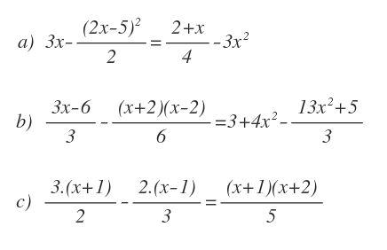

**Sumas, restas, divisiones y multiplicación**

-Sumas ( + ) -Restas ( - ) -Divisiones ( / ) -Multiplicación ( * )

```r
x<-1
a<-3
b<-5
y=20
(a*(x+b))/y
```

Raíz cuadrada (sqrt())

```r
sqrt(9)
```

Logaritmos y exponencias

```r
x<-5
log(x) # logaritmo natural
log(x,base=10)
```

```r
exp(x) # exponente natural
exp(x)
```

**Notación científica (“E”)**

```r
1797819191730111110009
```

```r
0.0000000008
```

E/e = número*10^potencia

### Objetos

En programación y en R, los objetos facilitan el trabajo con grandes cantidades de datos y código, ya que podemos almacenar datos, letras, nombre o códigos en un objeto y realizar análisis o programar con ellos.Un objeto es un símbolo (palabra, palabra con números o palabras con puntos), nunca se inician con un número, siempre con alguna letra.

> **Cómo se usa** 1a -> no es correcto a1 -> es correcto